# Exploring Active Travel Open Data

diarmuid.lloyd@gmail.com

```r
library(httr)
library(jsonlite)
library(tidyverse)
library(hrbrthemes)

hrbrthemes::import_roboto_condensed()
```

```
## You will likely need to install these fonts on your system as well.
##
## You can find them in [/Library/Frameworks/R.framework/Versions/4.0/Resources/library/hrbrthemes/fonts/roboto-condensed]
```

This is a notebook for recording different ways of accessing, and early data exploration, of the [Active Travel Open Data portal](https://usmart.io/org/cyclingscotland/).

# Live counter data using API

The last 1000 trips can be accessed using the API (you can control this using the `limit` query parameter). This will be good for creating apps, or where we just need most recent data. The following chunks summarise how to access it. A `status_code()` return of 200 means our request has succeeded.

## Example

In this example, let’s fetch the last four weeks of counts.

```r
four_weeks_ago <- as.Date(Sys.time() )- 28

four_weeks <- seq.Date(from = four_weeks_ago, to = Sys.Date(),by="day")
```

Using `purrr`, query each of these dates using the API and save everything in a dataframe.

```r
data <- purrr::map_df(
  four_weeks,
  .f = function(.x) {
    daily_counts <-
      GET(
        "https://api.usmart.io/org/d1b773fa-d2bd-4830-b399-ecfd18e832f3/7aa487cd-3cd5-405b-850e-1e2ac317816c/latest/urql",
        query  = list("startTime" = .x)
      )

    jsonlite::fromJSON(rawToChar(daily_counts$content))

  }
)

data <- data %>% mutate(startTime = lubridate::as_datetime(startTime))
```

Here, we do a very simple line plot of the accessed data of all counters.

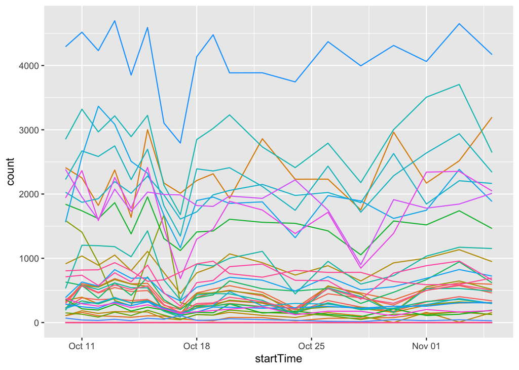

```r
data %>% group_by(location) %>%
  ggplot(aes(x = startTime, count, colour = location)) +
  geom_line() +
  theme(legend.position = "none")
```

We can see that it’s not quite live. Today’s date is 2021-11-07, while the latest in the API call here was 2021-11-05.

```r
data %>% group_by( location) %>%
  summarise(four_week_total = sum(count)) %>%
  arrange(desc(four_week_total)) %>%
  DT::datatable()
```

|  | location | four_week_total |
| --- | --- | --- |
| 1 | North Meadow Walk, Main Path | 77776 |
| 2 | Melville Drive Link | 54362 |
| 3 | Bruntsfield Place Northbound | 44058 |
| 4 | Melville Drive Main Path | 43691 |
| 5 | Morrison Street | 38672 |
| 6 | Melville Drive Northbound | 38537 |
| 7 | Rodney Street Tunnel | 35699 |
| 8 | Roseburn Path | 32960 |
| 9 | Harrison Park | 29156 |
| 10 | Mayfield Road Southbound | 17558 |

[output cut: 49 more lines]

# Full datasets

The full dataset can be downloaded for each of:

- Daily bicycle counts
- Hourly bicycle counts
- Just Eat bicycle hire counts

As you might expect, these are rather large datasets, ranging 100MB-200MB.

# Daily bicycle counts

First read the data.

```r
df_od <- read_csv("data/cycling-scotland-edinburgh-daily-counts.csv")
glimpse(df_od)
```

```
## Rows: 1,408,920
## Columns: 10
## $ area      <chr> "Edinburgh", "Edinburgh", "Edinburgh", "Edinburgh", "Edinbur…
## $ count     <dbl> 0, 0, 0, 0, 0, 0, 0, 0, 0, 0, 0, 0, 0, 0, 0, 0, 0, 0, 0, 0, …
## $ endTime   <dttm> 2019-07-21 11:00:00, 2019-07-21 12:00:00, 2019-07-21 15:00:…
## $ latitude  <dbl> 55.96676, 55.96676, 55.96676, 55.96676, 55.96676, 55.96676, …
## $ location  <chr> "Crammond Brigg", "Crammond Brigg", "Crammond Brigg", "Cramm…
## $ longitude <dbl> -3.31957, -3.31957, -3.31957, -3.31957, -3.31957, -3.31957, …
## $ provider  <chr> "City of Edinburgh Council", "City of Edinburgh Council", "C…
## $ siteID    <chr> "EDH55500017", "EDH55500017", "EDH55500017", "EDH55500017", …
## $ startTime <dttm> 2019-07-21 10:00:00, 2019-07-21 11:00:00, 2019-07-21 14:00:…
## $ usmart_id <chr> "3dac7874964515dd7facd6b952615ccc", "056648af14c7ca7709c8169…
```

```r
df_od %>% group_by(startTime) %>% summarise(count)
```

```
## # A tibble: 1,408,920 x 2
## # Groups:   startTime [23,880]
##    startTime           count
##    <dttm>              <dbl>
##  1 2019-01-01 00:00:00    20
##  2 2019-01-01 00:00:00    50
##  3 2019-01-01 00:00:00     0
##  4 2019-01-01 00:00:00     0
##  5 2019-01-01 00:00:00     2
##  6 2019-01-01 00:00:00     1
##  7 2019-01-01 00:00:00     0
##  8 2019-01-01 00:00:00     0
##  9 2019-01-01 00:00:00     0
## 10 2019-01-01 00:00:00     0
## # … with 1,408,910 more rows
```

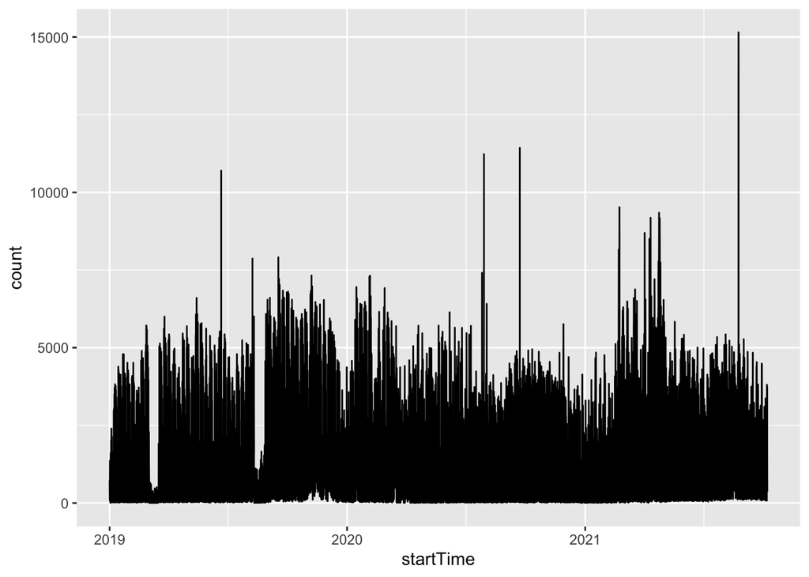

```r
df_od %>%
  group_by(startTime) %>%
  summarise(count = sum(count)) %>%
  ggplot(aes(x = startTime, y = count)) +
  geom_line()
```

# Adding useful variables

```r
# Probably weekend effects at play, so create a weekend flag.
 df_od <- df_od %>%
  mutate(weekend = if_else(lubridate::wday(startTime) %in% c(1,7), TRUE, FALSE ) ,
         day = lubridate::wday(startTime))

# Week starting flag, to allow summing trips in a given week
 df_od <- df_od %>%
  mutate(week_starting = lubridate::floor_date(startTime, unit = "week"))
```

# Checking the stations of interest

**On Road - SfP**

**On Road - Non SfP**

- 052 A8 Wester Coates

**Off Road - Non SfP**

- 015 Middle Meadow Walk

Manually construct a tribble which holds the stations of interest, with a SpF flag, then match that in to the main dataset.

```r
df_od %>% count(location,siteID)
```

```
## # A tibble: 59 x 3
##    location                               siteID          n
##    <chr>                                  <chr>       <int>
##  1 A8 Corstorphine Road                   EDH0029     23880
##  2 A8 Wester Coates                       EDH0052     23880
##  3 A90 Deans Bridge                       EDH0035     23880
##  4 Blacket Avenue                         EDH0051     23880
##  5 Blackhall (Dial-Up CA)                 EDH55500005 23880
##  6 Bruntsfield Place Northbound           EDH0038     23880
##  7 Bruntsfield Place Southbound           EDH0039     23880
##  8 Carrick Knowe Golf Course (Dial-Up CA) EDH55500013 23880
##  9 Carrington Road Eastbound              EDH0049     23880
## 10 Carrington Road Westbound              EDH0050     23880
## # … with 49 more rows
```

```r
site_id <- tribble(~siteID, ~sfp,
                    "EDH0035", "on-road SfP",
                    "EDH0031", "on-road SfP",
                   "EDH0048", "on-road SfP",
                   "EDH0039", "on-road SfP",
                   "EDH0052", "on-road non-SfP",
                   "EDH55500015", "off-road non-SfP") %>%
  mutate(sfp = as.factor(sfp))


df_od <- left_join(df_od,site_id, by = "siteID")
```

We now filter the data for those stations, and plot.

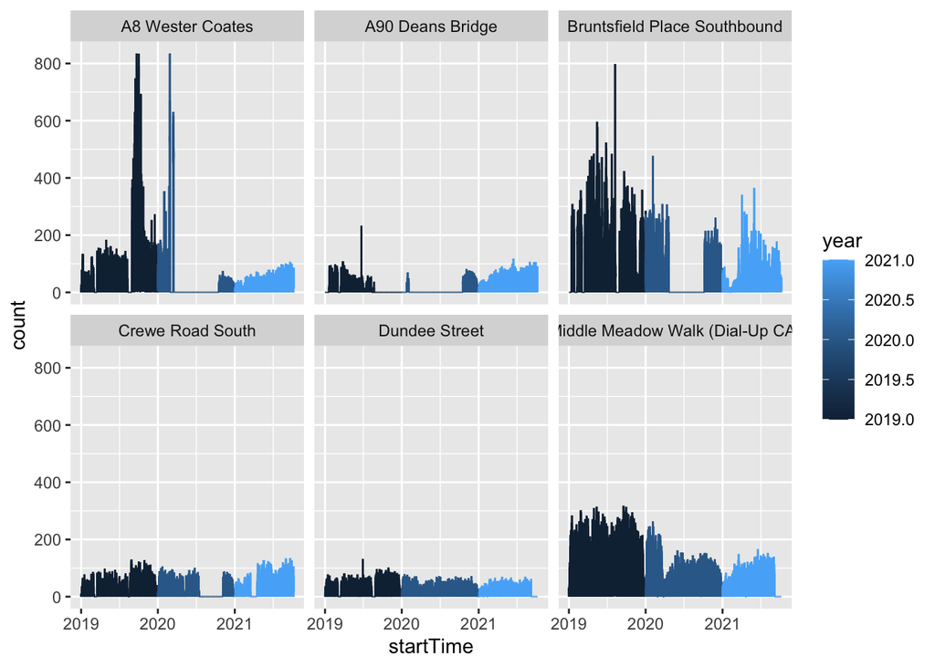

```r
df_f <- df_od %>% filter( siteID %in% site_id$siteID ) %>%
  mutate(year =lubridate::year(startTime) )

df_f %>%
  ggplot() +
  geom_line(aes(x = startTime, y = count, colour= year)) +
  facet_wrap(~location)
```

Weekly totals, ignoring any dodgy data, etc.

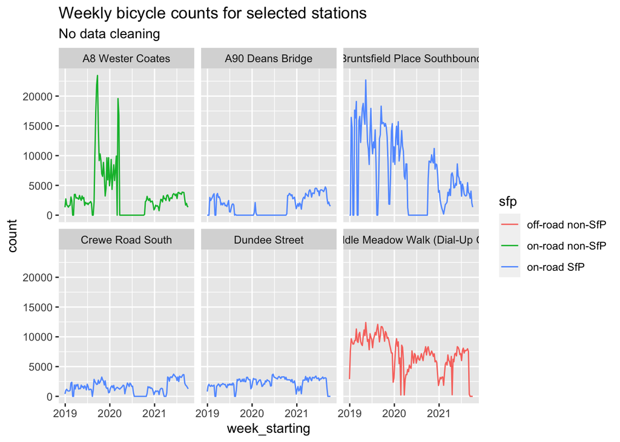

```r
df_f %>% group_by(siteID,location,sfp,week_starting) %>%
  summarise(count = sum(count, na.rm = TRUE)) %>%
  ggplot() +
    geom_line(aes(x = week_starting, y = count, colour = sfp)) +
  facet_wrap(~location) +

  labs(title = "Weekly bicycle counts for selected stations",
       subtitle = "No data cleaning")
```

```r
ggsave("output/weekly_bike_counts_selected_stations.png", plot = last_plot())
```

The distribution of total daily counts per year might be more helpful. Here, we compare 2019 and 2021:

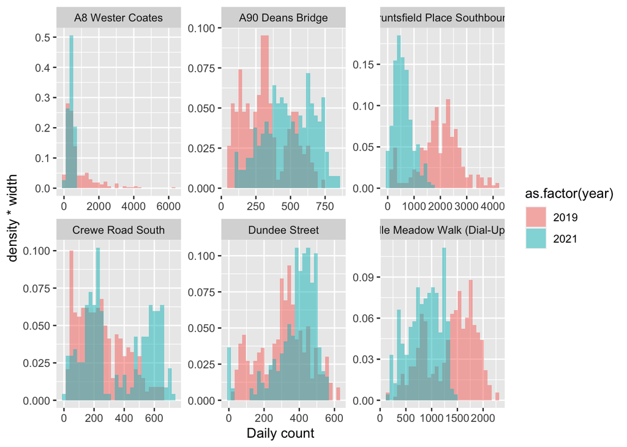

```r
bin_width = 50

df_f %>% group_by(siteID,location,year,week_starting, day) %>%
  filter(count > 0,
         year ==2019 | year==2021) %>%
  summarise(count = sum(count, na.rm = TRUE)) %>%


  ggplot(aes(x = count, group = year, fill = as.factor(year))) +
  geom_histogram(
    aes(y = stat(density*width)),
    alpha = 0.5, position = "identity") +
  facet_wrap(~location, scales = "free") +
  scale_x_continuous(name = "Daily count")
```

```r
ggsave("output/daily_counts_2019_2020_histogram_selected_stations.png", plot = last_plot())
```